# Differential Gene Expression Analysis Part 1

You Zhou

February 28, 2021

# Introduction

Differential expression analysis means taking the normalized read count data and performing statistical analysis to discover quantitative changes in expression levels between experimental groups. For example, we use statistical testing to decide whether, for a given gene, an observed difference in read counts is significant, that is, whether it is greater than what would be expected just due to natural random variation.

For a normal workflow, we need to first map the reads. Then we will do the counting step. After the counting step we can do the differential gene expression analysis with the tool like `edgeR` or `DESeq2`.

This coding tasks is about the downstream analysis after we get the result from `DESeq` function with `DESeq2` package. For doing the incoming tasks, the following package are recommended.

```r
## Load the suggested packages
library(DESeq2)
library(dplyr)
library(ggplot2)
library(ggrepel)
```

# Tasks

## Task1

Loading the `rds` files that I shared in the slack as a vector `dds`.

## Task2

Generating a *principal components analysis* (PCA) plot with *all the genes*. And think about the meaning of the PCA plot.

**Tips**: the package `DESeq2` may help.

## Task3

In the test data set, we have two condition `KO` and `WT`. Please find out the log2 fold change of gene expression upon the `KO` treatment, i.e. the fold change of gene expression from `WT` to `KO`.

**Tips**: for the task 2 you can get help from [DESeq2](https://bioconductor.org/packages/release/bioc/vignettes/DESeq2/inst/doc/DESeq2.html) vignettes.

## Task4

A `MA plot` is a type of scatterplot that shows gene expression changes (log2 fold change) versus the gene abundance. The `MA plot` highlights an important property of RNA-seq data. For the task4, please generate a `MA plot` to show the genes which receive a significant regulation upon the `KO` treatment. And think about how can we make the `MA plot` more clear by move the gene dots with low expression level.

**Tips**: `padj` in the output means the adjusted P-value.

Example of `MA plot`:

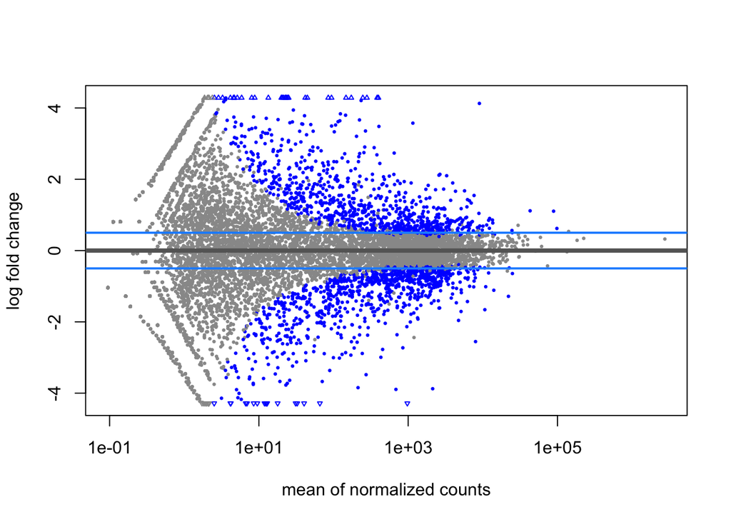

## Task5

Generating an MA plot with the label of top 5 down&up (based on the padj) regulated gene ID.

**Tips**: the package `ggplot2` and `ggrepel` may help here.

## Task6

A `volcano plot` is a type of scatterplot that shows statistical significance (P value) versus magnitude of change (fold change). It enables quick visual identification of genes with large fold changes that are also statistically significant. Please try to generate an `volcano` plot with the label of top 5 down&up (based on the padj) regulated gene ID.

**Tips**: the package `ggplot2` and `ggrepel` may help here.

Example:

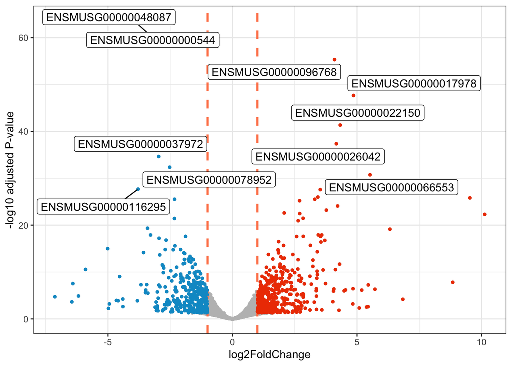